# Quickstart

**This is a very quick non-imaging introduction to Nipype workflows. For more comprehensive introduction, check the next section of the tutorial.**

[figure not shown]

- [Existing documentation](http://nipype.readthedocs.io/en/latest/)
- [Visualizing the evolution of Nipype](https://www.youtube.com/watch?v=cofpD1lhmKU)
- This notebook taken from [reproducible-imaging repository](https://github.com/ReproNim/reproducible-imaging)

#### Import a few things from nipype

```python
import os
from nipype import Workflow, Node, Function
```

Creating Workflow with one Node that adds two numbers

```python
def sum(a, b):
    return a + b

wf = Workflow('hello')

adder = Node(Function(input_names=['a', 'b'],
                      output_names=['sum'],
                      function=sum),
             name='a_plus_b')

adder.inputs.a = 1
adder.inputs.b = 3

wf.add_nodes([adder])

wf.base_dir = os.getcwd()

eg = wf.run()

list(eg.nodes())[0].result.outputs
```

```
180325-17:12:44,400 workflow INFO:
	 Workflow hello settings: ['check', 'execution', 'logging', 'monitoring']
180325-17:12:44,406 workflow INFO:
	 Running serially.
180325-17:12:44,408 workflow INFO:
	 [Node] Setting-up "hello.a_plus_b" in "/home/neuro/nipype_tutorial/notebooks/hello/a_plus_b".
180325-17:12:44,411 workflow INFO:
	 [Node] Outdated cache found for "hello.a_plus_b".
180325-17:12:44,594 workflow INFO:
	 [Node] Running "a_plus_b" ("nipype.interfaces.utility.wrappers.Function")
180325-17:12:44,601 workflow INFO:
	 [Node] Finished "hello.a_plus_b".
```

```
sum = 4
```

Creating a second node and connecting to the `hello` Workflow

```python
def concat(a, b):
    return [a, b]


concater = Node(Function(input_names=['a', 'b'],
                         output_names=['some_list'],
                         function=concat),
                name='concat_a_b')

wf.connect(adder, 'sum', concater, 'a')
concater.inputs.b = 3

eg = wf.run()
print(eg.nodes())
```

```
180325-17:12:44,647 workflow INFO:
	 Workflow hello settings: ['check', 'execution', 'logging', 'monitoring']
180325-17:12:44,653 workflow INFO:
	 Running serially.
180325-17:12:44,655 workflow INFO:
	 [Node] Setting-up "hello.a_plus_b" in "/home/neuro/nipype_tutorial/notebooks/hello/a_plus_b".
180325-17:12:44,657 workflow INFO:
	 [Node] Outdated cache found for "hello.a_plus_b".
180325-17:12:44,662 workflow INFO:
	 [Node] Running "a_plus_b" ("nipype.interfaces.utility.wrappers.Function")
180325-17:12:44,672 workflow INFO:
	 [Node] Finished "hello.a_plus_b".
180325-17:12:44,673 workflow INFO:
	 [Node] Setting-up "hello.concat_a_b" in "/home/neuro/nipype_tutorial/notebooks/hello/concat_a_b".
180325-17:12:44,685 workflow INFO:
	 [Node] Outdated cache found for "hello.concat_a_b".
180325-17:12:44,691 workflow INFO:
	 [Node] Running "concat_a_b" ("nipype.interfaces.utility.wrappers.Function")
180325-17:12:44,698 workflow INFO:
	 [Node] Finished "hello.concat_a_b".
[<nipype.pipeline.engine.nodes.Node object at 0x7ff1db9829b0>, <nipype.pipeline.engine.nodes.Node object at 0x7ff1db982940>]
```

And we can check results of our Workflow, we should see a list:

```python
list(eg.nodes())[-1].result.outputs
```

```
some_list = [4, 3]
```

We will try to add additional Node that adds one:

```python
def plus_one(a):
    return a + 1

plusone = Node(Function(input_names=['a'],
                        output_names=['out'],
                        function=plus_one),
               name='add_1')

wf.connect(concater, 'some_list', plusone, 'a')

try:
    eg = wf.run()
except(RuntimeError) as err:
    print("RuntimeError:", err)
else:
    raise
```

```
180325-17:12:44,742 workflow INFO:
	 Workflow hello settings: ['check', 'execution', 'logging', 'monitoring']
180325-17:12:44,750 workflow INFO:
	 Running serially.
180325-17:12:44,753 workflow INFO:
	 [Node] Setting-up "hello.a_plus_b" in "/home/neuro/nipype_tutorial/notebooks/hello/a_plus_b".
180325-17:12:44,756 workflow INFO:
	 [Node] Cached "hello.a_plus_b" - collecting precomputed outputs
180325-17:12:44,756 workflow INFO:
	 [Node] "hello.a_plus_b" found cached.
180325-17:12:44,758 workflow INFO:
	 [Node] Setting-up "hello.concat_a_b" in "/home/neuro/nipype_tutorial/notebooks/hello/concat_a_b".
180325-17:12:44,761 workflow INFO:
	 [Node] Outdated cache found for "hello.concat_a_b".
180325-17:12:44,765 workflow INFO:
	 [Node] Running "concat_a_b" ("nipype.interfaces.utility.wrappers.Function")
180325-17:12:44,771 workflow INFO:
	 [Node] Finished "hello.concat_a_b".
180325-17:12:44,774 workflow INFO:
	 [Node] Setting-up "hello.add_1" in "/home/neuro/nipype_tutorial/notebooks/hello/add_1".
180325-17:12:44,802 workflow INFO:
	 [Node] Running "add_1" ("nipype.interfaces.utility.wrappers.Function")
180325-17:12:44,807 workflow WARNING:
	 [Node] Error on "hello.add_1" (/home/neuro/nipype_tutorial/notebooks/hello/add_1)
180325-17:12:44,811 workflow ERROR:
	 Node add_1 failed to run on host ed2f682e361f.
180325-17:12:44,815 workflow ERROR:
	 Saving crash info to /home/neuro/nipype_tutorial/notebooks/crash-20180325-171244-neuro-add_1-fa6f83b0-935a-4809-bd48-8a5b32fdde59.pklz
Traceback (most recent call last):
  File "/opt/conda/envs/neuro/lib/python3.6/site-packages/nipype/pipeline/plugins/linear.py", line 44, in run
    node.run(updatehash=updatehash)
  File "/opt/conda/envs/neuro/lib/python3.6/site-packages/nipype/pipeline/engine/nodes.py", line 479, in run
    result = self._run_interface(execute=True)
  File "/opt/conda/envs/neuro/lib/python3.6/site-packages/nipype/pipeline/engine/nodes.py", line 563, in _run_interface
    return self._run_command(execute)
  File "/opt/conda/envs/neuro/lib/python3.6/site-packages/nipype/pipeline/engine/nodes.py", line 642, in _run_command
    result = self._interface.run(cwd=outdir)
  File "/opt/conda/envs/neuro/lib/python3.6/site-packages/nipype/interfaces/base/core.py", line 516, in run
    runtime = self._run_interface(runtime)
  File "/opt/conda/envs/neuro/lib/python3.6/site-packages/nipype/interfaces/utility/wrappers.py", line 144, in _run_interface
    out = function_handle(**args)
  File "<string>", line 2, in plus_one
TypeError: can only concatenate list (not "int") to list

180325-17:12:44,817 workflow INFO:
180325-17:12:44,818 workflow ERROR:
	 could not run node: hello.add_1
180325-17:12:44,820 workflow INFO:
	 crashfile: /home/neuro/nipype_tutorial/notebooks/crash-20180325-171244-neuro-add_1-fa6f83b0-935a-4809-bd48-8a5b32fdde59.pklz
180325-17:12:44,821 workflow INFO:
RuntimeError: Workflow did not execute cleanly. Check log for details
```

This time the workflow didn't execute cleanly and we got an error. We can use `nipypecli` to read the crashfile (note, that if you have multiple crashfiles in the directory you'll have to provide a full name):

```python
!nipypecli crash /home/neuro/nipype_tutorial/notebooks/crash*
```

[output not shown]

Let's try using MapNode

```python
from nipype import MapNode

plusone = MapNode(Function(input_names=['a'],
                           output_names=['out'],
                           function=plus_one),
                  iterfield=['a'],
                  name='add_1')

wf = Workflow('hello_mapnode')

adder = Node(Function(input_names=['a', 'b'],
                      output_names=['sum'],
                      function=sum),
             name='a_plus_b')

adder.inputs.a = 1
adder.inputs.b = 3
wf.connect(adder, 'sum', concater, 'a')
concater.inputs.b = 3

wf.connect(concater, 'some_list', plusone, 'a')

wf.base_dir = os.getcwd()

eg = wf.run()
print(eg.nodes())
```

```
180325-17:12:46,704 workflow INFO:
	 Workflow hello_mapnode settings: ['check', 'execution', 'logging', 'monitoring']
180325-17:12:46,711 workflow INFO:
	 Running serially.
180325-17:12:46,711 workflow INFO:
	 [Node] Setting-up "hello_mapnode.a_plus_b" in "/home/neuro/nipype_tutorial/notebooks/hello_mapnode/a_plus_b".
180325-17:12:46,743 workflow INFO:
	 [Node] Cached "hello_mapnode.a_plus_b" - collecting precomputed outputs
180325-17:12:46,744 workflow INFO:
	 [Node] "hello_mapnode.a_plus_b" found cached.
180325-17:12:46,745 workflow INFO:
	 [Node] Setting-up "hello.concat_a_b" in "/home/neuro/nipype_tutorial/notebooks/hello/concat_a_b".
180325-17:12:46,748 workflow INFO:
	 [Node] Cached "hello.concat_a_b" - collecting precomputed outputs
180325-17:12:46,748 workflow INFO:
	 [Node] "hello.concat_a_b" found cached.
180325-17:12:46,749 workflow INFO:
	 [Node] Setting-up "hello_mapnode.add_1" in "/home/neuro/nipype_tutorial/notebooks/hello_mapnode/add_1".
180325-17:12:46,764 workflow INFO:
	 [Node] "hello_mapnode.add_1" found cached.
[<nipype.pipeline.engine.nodes.Node object at 0x7ff1db89e208>, <nipype.pipeline.engine.nodes.Node object at 0x7ff1db89e358>, <nipype.pipeline.engine.nodes.MapNode object at 0x7ff1db89e438>]
```

Now the workflow finished without problems, let's see the results from `hello.add_1`:

```python
print(list(eg.nodes())[2].result.outputs)
```

```
Bunch(out=[5, 4])
```

And now we will run the example with `iterables`:

```python
adder.iterables = ('a', [1, 2])
adder.inputs.b = 2

eg = wf.run()
print(eg.nodes())
```

```
180325-17:12:46,789 workflow INFO:
	 Workflow hello_mapnode settings: ['check', 'execution', 'logging', 'monitoring']
180325-17:12:46,801 workflow INFO:
	 Running serially.
180325-17:12:46,802 workflow INFO:
	 [Node] Setting-up "hello_mapnode.a_plus_b" in "/home/neuro/nipype_tutorial/notebooks/hello_mapnode/_a_2/a_plus_b".
180325-17:12:46,805 workflow INFO:
	 [Node] Cached "hello_mapnode.a_plus_b" - collecting precomputed outputs
180325-17:12:46,807 workflow INFO:
	 [Node] "hello_mapnode.a_plus_b" found cached.
180325-17:12:46,809 workflow INFO:
	 [Node] Setting-up "hello.concat_a_b" in "/home/neuro/nipype_tutorial/notebooks/hello/_a_2/concat_a_b".
180325-17:12:46,813 workflow INFO:
	 [Node] Cached "hello.concat_a_b" - collecting precomputed outputs
180325-17:12:46,814 workflow INFO:
	 [Node] "hello.concat_a_b" found cached.
180325-17:12:46,815 workflow INFO:
	 [Node] Setting-up "hello_mapnode.add_1" in "/home/neuro/nipype_tutorial/notebooks/hello_mapnode/_a_2/add_1".
180325-17:12:46,853 workflow INFO:
	 [Node] "hello_mapnode.add_1" found cached.
180325-17:12:46,855 workflow INFO:
	 [Node] Setting-up "hello_mapnode.a_plus_b" in "/home/neuro/nipype_tutorial/notebooks/hello_mapnode/_a_1/a_plus_b".
180325-17:12:46,913 workflow INFO:
	 [Node] Cached "hello_mapnode.a_plus_b" - collecting precomputed outputs
180325-17:12:46,914 workflow INFO:
	 [Node] "hello_mapnode.a_plus_b" found cached.
180325-17:12:46,914 workflow INFO:
	 [Node] Setting-up "hello.concat_a_b" in "/home/neuro/nipype_tutorial/notebooks/hello/_a_1/concat_a_b".
180325-17:12:46,918 workflow INFO:
	 [Node] Cached "hello.concat_a_b" - collecting precomputed outputs
180325-17:12:46,919 workflow INFO:
	 [Node] "hello.concat_a_b" found cached.
180325-17:12:46,920 workflow INFO:
	 [Node] Setting-up "hello_mapnode.add_1" in "/home/neuro/nipype_tutorial/notebooks/hello_mapnode/_a_1/add_1".
180325-17:12:46,958 workflow INFO:
	 [Node] "hello_mapnode.add_1" found cached.
[<nipype.pipeline.engine.nodes.Node object at 0x7ff1db9f8e80>, <nipype.pipeline.engine.nodes.MapNode object at 0x7ff1db9f8a20>, <nipype.pipeline.engine.nodes.Node object at 0x7ff1db925b00>, <nipype.pipeline.engine.nodes.Node object at 0x7ff1db925438>, <nipype.pipeline.engine.nodes.MapNode object at …
```

```python
list(eg.nodes())[5].result.outputs
```

```
sum = 4
```

```python
wf.write_graph(graph2use='exec')
```

```
180325-17:12:47,200 workflow INFO:
	 Generated workflow graph: /home/neuro/nipype_tutorial/notebooks/hello_mapnode/graph.png (graph2use=exec, simple_form=True).
```

```
'/home/neuro/nipype_tutorial/notebooks/hello_mapnode/graph.png'
```

```python
from IPython.display import Image
```

We can plot a general structure of the workflow:

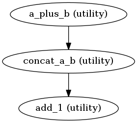

```python
Image("hello_mapnode/graph.png")
```

And more detailed structure with all nodes:

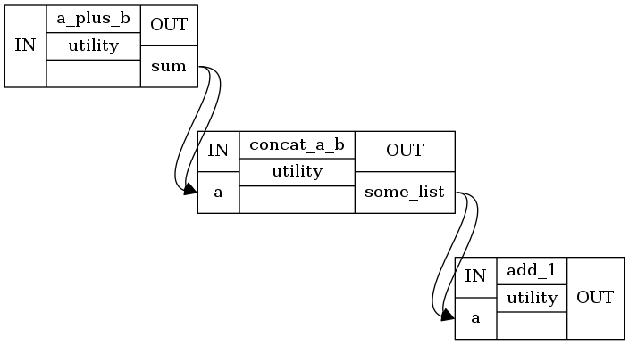

```python
Image("hello_mapnode/graph_detailed.png")
```

We will introduce another iterables, for the concater Node:

```python
concater.iterables = ('b', [3, 4])
eg = wf.run()
eg.nodes();
```

```
180325-17:12:47,240 workflow INFO:
	 Workflow hello_mapnode settings: ['check', 'execution', 'logging', 'monitoring']
180325-17:12:47,258 workflow INFO:
	 Running serially.
180325-17:12:47,259 workflow INFO:
	 [Node] Setting-up "hello_mapnode.a_plus_b" in "/home/neuro/nipype_tutorial/notebooks/hello_mapnode/_a_2/a_plus_b".
180325-17:12:47,262 workflow INFO:
	 [Node] Cached "hello_mapnode.a_plus_b" - collecting precomputed outputs
180325-17:12:47,265 workflow INFO:
	 [Node] "hello_mapnode.a_plus_b" found cached.
180325-17:12:47,267 workflow INFO:
	 [Node] Setting-up "hello.concat_a_b" in "/home/neuro/nipype_tutorial/notebooks/hello/_a_2/_b_4/concat_a_b".
180325-17:12:47,273 workflow INFO:
	 [Node] Cached "hello.concat_a_b" - collecting precomputed outputs
180325-17:12:47,274 workflow INFO:
	 [Node] "hello.concat_a_b" found cached.
180325-17:12:47,275 workflow INFO:
	 [Node] Setting-up "hello_mapnode.add_1" in "/home/neuro/nipype_tutorial/notebooks/hello_mapnode/_a_2/_b_4/add_1".
180325-17:12:47,279 workflow INFO:
	 [Node] Outdated cache found for "hello_mapnode.add_1".
180325-17:12:47,288 workflow INFO:
	 [Node] Setting-up "_add_10" in "/home/neuro/nipype_tutorial/notebooks/hello_mapnode/_a_2/_b_4/add_1/mapflow/_add_10".
180325-17:12:47,290 workflow INFO:
	 [Node] Outdated cache found for "_add_10".
180325-17:12:47,294 workflow INFO:
	 [Node] Running "_add_10" ("nipype.interfaces.utility.wrappers.Function")
180325-17:12:47,300 workflow INFO:
	 [Node] Finished "_add_10".
180325-17:12:47,304 workflow INFO:
	 [Node] Setting-up "_add_11" in "/home/neuro/nipype_tutorial/notebooks/hello_mapnode/_a_2/_b_4/add_1/mapflow/_add_11".
180325-17:12:47,306 workflow INFO:
	 [Node] Outdated cache found for "_add_11".
180325-17:12:47,309 workflow INFO:
	 [Node] Running "_add_11" ("nipype.interfaces.utility.wrappers.Function")
180325-17:12:47,317 workflow INFO:
	 [Node] Finished "_add_11".
180325-17:12:47,321 workflow INFO:
	 [Node] Finished "hello_mapnode.add_1".
180325-17:12:47,323 workflow INFO:
	 [Node] Setting-up "hello.concat_a_b" in "/home/neuro/nipype_tutorial/notebooks/hello/_a_2/_b_3/concat_a_b".
```

[output cut: 73 more lines]

```
	 [Node] Outdated cache found for "_add_10".
180325-17:12:47,493 workflow INFO:
	 [Node] Running "_add_10" ("nipype.interfaces.utility.wrappers.Function")
180325-17:12:47,499 workflow INFO:
	 [Node] Finished "_add_10".
180325-17:12:47,502 workflow INFO:
	 [Node] Setting-up "_add_11" in "/home/neuro/nipype_tutorial/notebooks/hello_mapnode/_a_1/_b_3/add_1/mapflow/_add_11".
180325-17:12:47,506 workflow INFO:
	 [Node] Outdated cache found for "_add_11".
180325-17:12:47,510 workflow INFO:
	 [Node] Running "_add_11" ("nipype.interfaces.utility.wrappers.Function")
180325-17:12:47,517 workflow INFO:
	 [Node] Finished "_add_11".
180325-17:12:47,521 workflow INFO:
	 [Node] Finished "hello_mapnode.add_1".
```

```python
wf.write_graph(graph2use='exec')
```

```
180325-17:12:47,742 workflow INFO:
	 Generated workflow graph: /home/neuro/nipype_tutorial/notebooks/hello_mapnode/graph.png (graph2use=exec, simple_form=True).
```

```
'/home/neuro/nipype_tutorial/notebooks/hello_mapnode/graph.png'
```

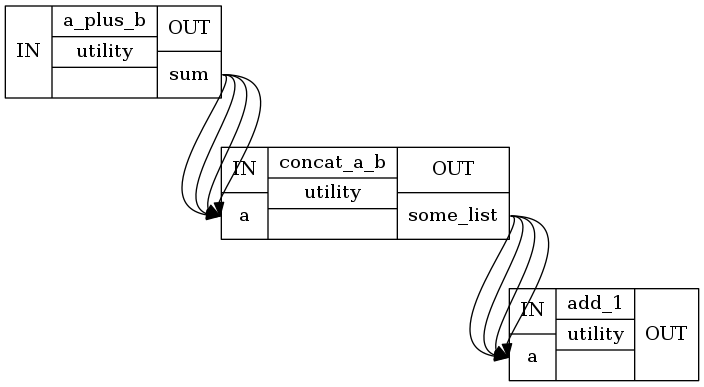

```python
Image("hello_mapnode/graph_detailed.png")
```

Now we will introduce JoinNode that allows us to merge results together:

```python
def merge_and_scale_data(data2):
    import numpy as np
    return (np.array(data2) * 1000).tolist()


from nipype import JoinNode
joiner = JoinNode(Function(input_names=['data2'],
                          output_names=['data_scaled'],
                          function=merge_and_scale_data),
                 name='join_scale_data',
                 joinsource=adder,
                 joinfield=['data2'])

wf.connect(plusone, 'out', joiner, 'data2')

eg = wf.run()
eg.nodes()
```

```
180325-17:12:47,778 workflow INFO:
	 Workflow hello_mapnode settings: ['check', 'execution', 'logging', 'monitoring']
180325-17:12:47,808 workflow INFO:
	 Running serially.
180325-17:12:47,810 workflow INFO:
	 [Node] Setting-up "hello_mapnode.a_plus_b" in "/home/neuro/nipype_tutorial/notebooks/hello_mapnode/_a_2/a_plus_b".
180325-17:12:47,813 workflow INFO:
	 [Node] Cached "hello_mapnode.a_plus_b" - collecting precomputed outputs
180325-17:12:47,815 workflow INFO:
	 [Node] "hello_mapnode.a_plus_b" found cached.
180325-17:12:47,816 workflow INFO:
	 [Node] Setting-up "hello.concat_a_b" in "/home/neuro/nipype_tutorial/notebooks/hello/_a_2/_b_4/concat_a_b".
180325-17:12:47,820 workflow INFO:
	 [Node] Cached "hello.concat_a_b" - collecting precomputed outputs
180325-17:12:47,823 workflow INFO:
	 [Node] "hello.concat_a_b" found cached.
180325-17:12:47,824 workflow INFO:
	 [Node] Setting-up "hello_mapnode.add_1" in "/home/neuro/nipype_tutorial/notebooks/hello_mapnode/_a_2/_b_4/add_1".
180325-17:12:47,828 workflow INFO:
	 [Node] Outdated cache found for "hello_mapnode.add_1".
180325-17:12:47,833 workflow INFO:
	 [Node] Setting-up "_add_10" in "/home/neuro/nipype_tutorial/notebooks/hello_mapnode/_a_2/_b_4/add_1/mapflow/_add_10".
180325-17:12:47,835 workflow INFO:
	 [Node] Outdated cache found for "_add_10".
180325-17:12:47,840 workflow INFO:
	 [Node] Running "_add_10" ("nipype.interfaces.utility.wrappers.Function")
180325-17:12:47,845 workflow INFO:
	 [Node] Finished "_add_10".
180325-17:12:47,849 workflow INFO:
	 [Node] Setting-up "_add_11" in "/home/neuro/nipype_tutorial/notebooks/hello_mapnode/_a_2/_b_4/add_1/mapflow/_add_11".
180325-17:12:47,852 workflow INFO:
	 [Node] Outdated cache found for "_add_11".
180325-17:12:47,858 workflow INFO:
	 [Node] Running "_add_11" ("nipype.interfaces.utility.wrappers.Function")
180325-17:12:47,864 workflow INFO:
	 [Node] Finished "_add_11".
180325-17:12:47,872 workflow INFO:
	 [Node] Finished "hello_mapnode.add_1".
180325-17:12:47,873 workflow INFO:
	 [Node] Setting-up "hello.concat_a_b" in "/home/neuro/nipype_tutorial/notebooks/hello/_a_2/_b_3/concat_a_b".
```

[output cut: 85 more lines]

```
	 [Node] Setting-up "_add_11" in "/home/neuro/nipype_tutorial/notebooks/hello_mapnode/_a_1/_b_3/add_1/mapflow/_add_11".
180325-17:12:48,37 workflow INFO:
	 [Node] Outdated cache found for "_add_11".
180325-17:12:48,43 workflow INFO:
	 [Node] Running "_add_11" ("nipype.interfaces.utility.wrappers.Function")
180325-17:12:48,49 workflow INFO:
	 [Node] Finished "_add_11".
180325-17:12:48,52 workflow INFO:
	 [Node] Finished "hello_mapnode.add_1".
180325-17:12:48,53 workflow INFO:
	 [Node] Setting-up "hello_mapnode.join_scale_data" in "/home/neuro/nipype_tutorial/notebooks/hello_mapnode/_b_3/join_scale_data".
180325-17:12:48,58 workflow INFO:
	 [Node] Cached "hello_mapnode.join_scale_data" - collecting precomputed outputs
180325-17:12:48,59 workflow INFO:
	 [Node] "hello_mapnode.join_scale_data" found cached.
```

```
NodeView((<nipype.pipeline.engine.nodes.JoinNode object at 0x7ff1db01b198>, <nipype.pipeline.engine.nodes.JoinNode object at 0x7ff1daf52e10>, <nipype.pipeline.engine.nodes.Node object at 0x7ff1daf4ffd0>, <nipype.pipeline.engine.nodes.MapNode object at 0x7ff1daf4f6d8>, <nipype.pipeline.engine.nodes.N…
```

Let's check the output of `hello.join_scale_data.a0` node:

```python
list(eg.nodes())[0].result.outputs
```

```
data_scaled = [[4000, 4000], [5000, 4000]]
```

```python
wf.write_graph(graph2use='exec')
```

```
180325-17:12:48,295 workflow INFO:
	 Generated workflow graph: /home/neuro/nipype_tutorial/notebooks/hello_mapnode/graph.png (graph2use=exec, simple_form=True).
```

```
'/home/neuro/nipype_tutorial/notebooks/hello_mapnode/graph.png'
```

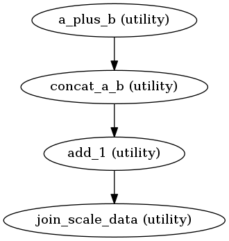

```python
Image("hello_mapnode/graph.png")
```

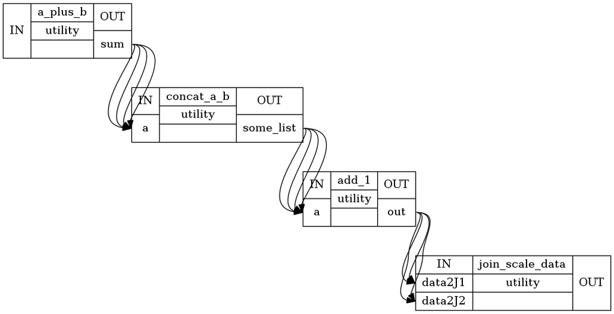

```python
Image("hello_mapnode/graph_detailed.png")
```

```python
%time eg = wf.run(plugin='MultiProc', plugin_args={'n_procs': 2})
```

```
180325-17:12:48,340 workflow INFO:
	 Workflow hello_mapnode settings: ['check', 'execution', 'logging', 'monitoring']
180325-17:12:48,365 workflow INFO:
	 Running in parallel.
180325-17:12:48,369 workflow INFO:
	 [MultiProc] Running 0 tasks, and 2 jobs ready. Free memory (GB): 53.94/53.94, Free processors: 2/2.
180325-17:12:48,421 workflow INFO:
	 [Job 0] Cached (hello_mapnode.a_plus_b).
180325-17:12:48,424 workflow INFO:
	 [Job 5] Cached (hello_mapnode.a_plus_b).
180325-17:12:50,372 workflow INFO:
	 [MultiProc] Running 0 tasks, and 4 jobs ready. Free memory (GB): 53.94/53.94, Free processors: 2/2.
180325-17:12:50,411 workflow INFO:
	 [Job 1] Cached (hello.concat_a_b).
180325-17:12:50,415 workflow INFO:
	 [Job 3] Cached (hello.concat_a_b).
180325-17:12:52,421 workflow INFO:
	 [Job 6] Cached (hello.concat_a_b).
180325-17:12:52,426 workflow INFO:
	 [Job 9] Cached (hello.concat_a_b).
180325-17:12:54,374 workflow INFO:
	 [MultiProc] Running 0 tasks, and 6 jobs ready. Free memory (GB): 53.94/53.94, Free processors: 2/2.
180325-17:12:54,418 workflow INFO:
	 [Job 12] Cached (_add_10).
180325-17:12:54,420 workflow INFO:
	 [Job 13] Cached (_add_11).
180325-17:12:56,375 workflow INFO:
	 [MultiProc] Running 0 tasks, and 7 jobs ready. Free memory (GB): 53.94/53.94, Free processors: 2/2.
180325-17:12:56,406 workflow INFO:
	 [Job 2] Cached (hello_mapnode.add_1).
180325-17:12:56,409 workflow INFO:
	 [Job 14] Cached (_add_10).
180325-17:12:58,377 workflow INFO:
	 [MultiProc] Running 0 tasks, and 5 jobs ready. Free memory (GB): 53.94/53.94, Free processors: 2/2.
180325-17:12:58,411 workflow INFO:
	 [Job 15] Cached (_add_11).
180325-17:12:58,413 workflow INFO:
	 [Job 16] Cached (_add_10).
180325-17:13:00,379 workflow INFO:
	 [MultiProc] Running 0 tasks, and 4 jobs ready. Free memory (GB): 53.94/53.94, Free processors: 2/2.
```

[output cut: 9 more lines]

```
	 [Job 18] Cached (_add_10).
180325-17:13:04,384 workflow INFO:
	 [MultiProc] Running 0 tasks, and 2 jobs ready. Free memory (GB): 53.94/53.94, Free processors: 2/2.
180325-17:13:04,415 workflow INFO:
	 [Job 8] Cached (hello_mapnode.join_scale_data).
180325-17:13:04,417 workflow INFO:
	 [Job 19] Cached (_add_11).
180325-17:13:06,388 workflow INFO:
	 [MultiProc] Running 0 tasks, and 1 jobs ready. Free memory (GB): 53.94/53.94, Free processors: 2/2.
180325-17:13:06,439 workflow INFO:
	 [Job 10] Cached (hello_mapnode.add_1).
180325-17:13:08,424 workflow INFO:
	 [Job 11] Cached (hello_mapnode.join_scale_data).
CPU times: user 538 ms, sys: 58.5 ms, total: 596 ms
Wall time: 22.1 s
```

```python
wf.base_dir = os.path.join(os.getcwd(), 'alt')
```

```python
%time eg = wf.run(plugin='MultiProc', plugin_args={'n_procs': 2})
```

```
180325-17:13:10,428 workflow INFO:
	 Workflow hello_mapnode settings: ['check', 'execution', 'logging', 'monitoring']
180325-17:13:10,472 workflow INFO:
	 Running in parallel.
180325-17:13:10,475 workflow INFO:
	 [MultiProc] Running 0 tasks, and 2 jobs ready. Free memory (GB): 53.94/53.94, Free processors: 2/2.
180325-17:13:10,553 workflow INFO:
	 [Job 0] Cached (hello_mapnode.a_plus_b).
180325-17:13:10,557 workflow INFO:
	 [Job 5] Cached (hello_mapnode.a_plus_b).
180325-17:13:12,480 workflow INFO:
	 [MultiProc] Running 0 tasks, and 4 jobs ready. Free memory (GB): 53.94/53.94, Free processors: 2/2.
180325-17:13:12,555 workflow INFO:
	 [Job 1] Cached (hello.concat_a_b).
180325-17:13:12,559 workflow INFO:
	 [Job 3] Cached (hello.concat_a_b).
180325-17:13:14,535 workflow INFO:
	 [Job 6] Cached (hello.concat_a_b).
180325-17:13:14,538 workflow INFO:
	 [Job 9] Cached (hello.concat_a_b).
180325-17:13:16,482 workflow INFO:
	 [MultiProc] Running 0 tasks, and 6 jobs ready. Free memory (GB): 53.94/53.94, Free processors: 2/2.
180325-17:13:16,651 workflow INFO:
	 [Job 12] Cached (_add_10).
180325-17:13:16,672 workflow INFO:
	 [Job 13] Cached (_add_11).
180325-17:13:18,484 workflow INFO:
	 [MultiProc] Running 0 tasks, and 7 jobs ready. Free memory (GB): 53.94/53.94, Free processors: 2/2.
180325-17:13:18,522 workflow INFO:
	 [Job 2] Cached (hello_mapnode.add_1).
180325-17:13:18,550 workflow INFO:
	 [Job 14] Cached (_add_10).
180325-17:13:20,486 workflow INFO:
	 [MultiProc] Running 0 tasks, and 5 jobs ready. Free memory (GB): 53.94/53.94, Free processors: 2/2.
180325-17:13:20,570 workflow INFO:
	 [Job 15] Cached (_add_11).
180325-17:13:20,576 workflow INFO:
	 [Job 16] Cached (_add_10).
180325-17:13:22,491 workflow INFO:
	 [MultiProc] Running 0 tasks, and 4 jobs ready. Free memory (GB): 53.94/53.94, Free processors: 2/2.
```

[output cut: 9 more lines]

```
	 [Job 18] Cached (_add_10).
180325-17:13:26,492 workflow INFO:
	 [MultiProc] Running 0 tasks, and 2 jobs ready. Free memory (GB): 53.94/53.94, Free processors: 2/2.
180325-17:13:26,683 workflow INFO:
	 [Job 8] Cached (hello_mapnode.join_scale_data).
180325-17:13:26,690 workflow INFO:
	 [Job 19] Cached (_add_11).
180325-17:13:28,494 workflow INFO:
	 [MultiProc] Running 0 tasks, and 1 jobs ready. Free memory (GB): 53.94/53.94, Free processors: 2/2.
180325-17:13:28,542 workflow INFO:
	 [Job 10] Cached (hello_mapnode.add_1).
180325-17:13:30,609 workflow INFO:
	 [Job 11] Cached (hello_mapnode.join_scale_data).
CPU times: user 568 ms, sys: 68.6 ms, total: 637 ms
Wall time: 22.1 s
```

```python
%time eg = wf.run(plugin='MultiProc', plugin_args={'n_procs': 2})
```

```
180325-17:13:32,667 workflow INFO:
	 Workflow hello_mapnode settings: ['check', 'execution', 'logging', 'monitoring']
180325-17:13:32,767 workflow INFO:
	 Running in parallel.
180325-17:13:32,857 workflow INFO:
	 [MultiProc] Running 0 tasks, and 2 jobs ready. Free memory (GB): 53.94/53.94, Free processors: 2/2.
180325-17:13:33,53 workflow INFO:
	 [Job 0] Cached (hello_mapnode.a_plus_b).
180325-17:13:33,65 workflow INFO:
	 [Job 5] Cached (hello_mapnode.a_plus_b).
180325-17:13:34,828 workflow INFO:
	 [MultiProc] Running 0 tasks, and 4 jobs ready. Free memory (GB): 53.94/53.94, Free processors: 2/2.
180325-17:13:34,902 workflow INFO:
	 [Job 1] Cached (hello.concat_a_b).
180325-17:13:34,921 workflow INFO:
	 [Job 3] Cached (hello.concat_a_b).
180325-17:13:36,909 workflow INFO:
	 [Job 6] Cached (hello.concat_a_b).
180325-17:13:36,943 workflow INFO:
	 [Job 9] Cached (hello.concat_a_b).
180325-17:13:38,832 workflow INFO:
	 [MultiProc] Running 0 tasks, and 6 jobs ready. Free memory (GB): 53.94/53.94, Free processors: 2/2.
180325-17:13:38,906 workflow INFO:
	 [Job 12] Cached (_add_10).
180325-17:13:38,913 workflow INFO:
	 [Job 13] Cached (_add_11).
180325-17:13:40,834 workflow INFO:
	 [MultiProc] Running 0 tasks, and 7 jobs ready. Free memory (GB): 53.94/53.94, Free processors: 2/2.
180325-17:13:40,915 workflow INFO:
	 [Job 2] Cached (hello_mapnode.add_1).
180325-17:13:40,923 workflow INFO:
	 [Job 14] Cached (_add_10).
180325-17:13:42,836 workflow INFO:
	 [MultiProc] Running 0 tasks, and 5 jobs ready. Free memory (GB): 53.94/53.94, Free processors: 2/2.
180325-17:13:42,882 workflow INFO:
	 [Job 15] Cached (_add_11).
180325-17:13:42,889 workflow INFO:
	 [Job 16] Cached (_add_10).
180325-17:13:44,839 workflow INFO:
	 [MultiProc] Running 0 tasks, and 4 jobs ready. Free memory (GB): 53.94/53.94, Free processors: 2/2.
```

[output cut: 9 more lines]

```
	 [Job 18] Cached (_add_10).
180325-17:13:48,842 workflow INFO:
	 [MultiProc] Running 0 tasks, and 2 jobs ready. Free memory (GB): 53.94/53.94, Free processors: 2/2.
180325-17:13:48,912 workflow INFO:
	 [Job 8] Cached (hello_mapnode.join_scale_data).
180325-17:13:48,933 workflow INFO:
	 [Job 19] Cached (_add_11).
180325-17:13:50,844 workflow INFO:
	 [MultiProc] Running 0 tasks, and 1 jobs ready. Free memory (GB): 53.94/53.94, Free processors: 2/2.
180325-17:13:50,890 workflow INFO:
	 [Job 10] Cached (hello_mapnode.add_1).
180325-17:13:52,892 workflow INFO:
	 [Job 11] Cached (hello_mapnode.join_scale_data).
CPU times: user 641 ms, sys: 54.7 ms, total: 696 ms
Wall time: 22.3 s
```

### Exercise 1

Create a workflow to calculate a sum of factorials of numbers from a range between $n_{min}$ and $n_{max}$, i.e.:

$$\sum _{k=n_{min}}^{n_{max}} k! = 0! + 1! +2! + 3! + \cdots$$

if $n_{min}=0$ and $n_{max}=3$ $$\sum _{k=0}^{3} k! = 0! + 1! +2! + 3! = 1 + 1 + 2 + 6 = 10$$

```python
#write your code here

# 1. write 3 functions: one that return a list of number from specific range,
#    second that returns n! (you can use math.factorial) and third that sums the elements from a list

# 2. create a workflow and define the working directory

# 3. define 3 nodes using Node and MapNode and connect them within the workflow

# 4. run the workflow and check the results
```

```python
from nipype import Workflow, Node, MapNode, Function
import os

def range_fun(n_min, n_max):
    return list(range(n_min, n_max+1))

def factorial(n):
    # print("FACTORIAL, {}".format(n))
    import math
    return math.factorial(n)

def summing(terms):
    return sum(terms)

wf_ex1 = Workflow('ex1')
wf_ex1.base_dir = os.getcwd()

range_nd = Node(Function(input_names=['n_min', 'n_max'],
                         output_names=['range_list'],
                         function=range_fun),
                name='range_list')

factorial_nd = MapNode(Function(input_names=['n'],
                                output_names=['fact_out'],
                                function=factorial),
                       iterfield=['n'],
                       name='factorial')

summing_nd = Node(Function(input_names=['terms'],
                           output_names=['sum_out'],
                           function=summing),
                  name='summing')


range_nd.inputs.n_min = 0
range_nd.inputs.n_max = 3

wf_ex1.add_nodes([range_nd])
wf_ex1.connect(range_nd, 'range_list', factorial_nd, 'n')
wf_ex1.connect(factorial_nd, 'fact_out', summing_nd, "terms")


eg = wf_ex1.run()
```

```
180325-17:13:55,19 workflow INFO:
	 Workflow ex1 settings: ['check', 'execution', 'logging', 'monitoring']
180325-17:13:55,32 workflow INFO:
	 Running serially.
180325-17:13:55,38 workflow INFO:
	 [Node] Setting-up "ex1.range_list" in "/home/neuro/nipype_tutorial/notebooks/ex1/range_list".
180325-17:13:55,78 workflow INFO:
	 [Node] Cached "ex1.range_list" - collecting precomputed outputs
180325-17:13:55,82 workflow INFO:
	 [Node] "ex1.range_list" found cached.
180325-17:13:55,85 workflow INFO:
	 [Node] Setting-up "ex1.factorial" in "/home/neuro/nipype_tutorial/notebooks/ex1/factorial".
180325-17:13:55,96 workflow INFO:
	 [Node] "ex1.factorial" found cached.
180325-17:13:55,98 workflow INFO:
	 [Node] Setting-up "ex1.summing" in "/home/neuro/nipype_tutorial/notebooks/ex1/summing".
180325-17:13:55,103 workflow INFO:
	 [Node] Cached "ex1.summing" - collecting precomputed outputs
180325-17:13:55,107 workflow INFO:
	 [Node] "ex1.summing" found cached.
```

let's print all nodes:

```python
eg.nodes()
```

```
NodeView((<nipype.pipeline.engine.nodes.Node object at 0x7ff1daf3d710>, <nipype.pipeline.engine.nodes.MapNode object at 0x7ff1daf3dba8>, <nipype.pipeline.engine.nodes.Node object at 0x7ff1daf3d588>))
```

the final result should be 10:

```python
list(eg.nodes())[2].result.outputs
```

```
sum_out = 10
```

we can also check the results of two other nodes:

```python
print(list(eg.nodes())[0].result.outputs)
print(list(eg.nodes())[1].result.outputs)
```

```
range_list = [0, 1, 2, 3]

Bunch(fact_out=[1, 1, 2, 6])
```

### Exercise 2

Create a workflow to calculate the following sum for chosen $n$ and five different values of $x$: $0$, $\frac{1}{2} \pi$, $\pi$, $\frac{3}{2} \pi$, and $ 2 \pi$.

$\sum _{{k=0}}^{{n}}{\frac {(-1)^{k}}{(2k+1)!}}x^{{2k+1}}\quad =x-{\frac {x^{3}}{3!}}+{\frac {x^{5}}{5!}}-\cdots $

```python
# write your solution here

# 1. write 3 functions: one that return a list of number from a range between 0 and some n,
#    second that returns a term for a specific k, and third that sums the elements from a list

# 2. create a workflow and define the working directory

# 3. define 3 nodes using Node and MapNode and connect them within the workflow

# 4. use iterables for 4 values of x

# 5. run the workflow and check the final results for every value of x
```

```python
# we can reuse function from previous exercise, but they need some edits
from nipype import Workflow, Node, MapNode, JoinNode, Function
import os
import math

def range_fun(n_max):
    return list(range(n_max+1))

def term(k, x):
    import math
    fract = math.factorial(2 * k + 1)
    polyn = x ** (2 * k + 1)
    return (-1)**k * polyn / fract

def summing(terms):
    return sum(terms)

wf_ex2 = Workflow('ex2')
wf_ex2.base_dir = os.getcwd()

range_nd = Node(Function(input_names=['n_max'],
                         output_names=['range_list'],
                         function=range_fun),
                name='range_list')

term_nd = MapNode(Function(input_names=['k', 'x'],
                           output_names=['term_out'],
                           function=term),
                  iterfield=['k'],
                  name='term')

summing_nd = Node(Function(input_names=['terms'],
                           output_names=['sum_out'],
                           function=summing),
                name='summing')


range_nd.inputs.n_max = 15

x_list = [0, 0.5 * math.pi, math.pi, 1.5 * math.pi, 2 * math.pi]

term_nd.iterables = ('x', x_list)

wf_ex2.add_nodes([range_nd])
wf_ex2.connect(range_nd, 'range_list', term_nd, 'k')
wf_ex2.connect(term_nd, 'term_out', summing_nd, "terms")


eg = wf_ex2.run()
```

```
180325-17:13:55,365 workflow INFO:
	 Workflow ex2 settings: ['check', 'execution', 'logging', 'monitoring']
180325-17:13:55,391 workflow INFO:
	 Running serially.
180325-17:13:55,398 workflow INFO:
	 [Node] Setting-up "ex2.range_list" in "/home/neuro/nipype_tutorial/notebooks/ex2/range_list".
180325-17:13:55,409 workflow INFO:
	 [Node] Cached "ex2.range_list" - collecting precomputed outputs
180325-17:13:55,415 workflow INFO:
	 [Node] "ex2.range_list" found cached.
180325-17:13:55,421 workflow INFO:
	 [Node] Setting-up "ex2.term" in "/home/neuro/nipype_tutorial/notebooks/ex2/_x_6.283185307179586/term".
180325-17:13:55,458 workflow INFO:
	 [Node] "ex2.term" found cached.
180325-17:13:55,463 workflow INFO:
	 [Node] Setting-up "ex2.summing" in "/home/neuro/nipype_tutorial/notebooks/ex2/_x_6.283185307179586/summing".
180325-17:13:55,477 workflow INFO:
	 [Node] Outdated cache found for "ex2.summing".
180325-17:13:55,486 workflow INFO:
	 [Node] Running "summing" ("nipype.interfaces.utility.wrappers.Function")
180325-17:13:55,498 workflow INFO:
	 [Node] Finished "ex2.summing".
180325-17:13:55,504 workflow INFO:
	 [Node] Setting-up "ex2.term" in "/home/neuro/nipype_tutorial/notebooks/ex2/_x_4.71238898038469/term".
180325-17:13:55,518 workflow INFO:
	 [Node] "ex2.term" found cached.
180325-17:13:55,524 workflow INFO:
	 [Node] Setting-up "ex2.summing" in "/home/neuro/nipype_tutorial/notebooks/ex2/_x_4.71238898038469/summing".
180325-17:13:55,536 workflow INFO:
	 [Node] Outdated cache found for "ex2.summing".
180325-17:13:55,550 workflow INFO:
	 [Node] Running "summing" ("nipype.interfaces.utility.wrappers.Function")
180325-17:13:55,561 workflow INFO:
	 [Node] Finished "ex2.summing".
180325-17:13:55,567 workflow INFO:
	 [Node] Setting-up "ex2.term" in "/home/neuro/nipype_tutorial/notebooks/ex2/_x_3.141592653589793/term".
180325-17:13:55,580 workflow INFO:
	 [Node] "ex2.term" found cached.
180325-17:13:55,588 workflow INFO:
	 [Node] Setting-up "ex2.summing" in "/home/neuro/nipype_tutorial/notebooks/ex2/_x_3.141592653589793/summing".
```

[output cut: 15 more lines]

```
	 [Node] Running "summing" ("nipype.interfaces.utility.wrappers.Function")
180325-17:13:55,726 workflow INFO:
	 [Node] Finished "ex2.summing".
180325-17:13:55,732 workflow INFO:
	 [Node] Setting-up "ex2.term" in "/home/neuro/nipype_tutorial/notebooks/ex2/_x_0/term".
180325-17:13:55,763 workflow INFO:
	 [Node] "ex2.term" found cached.
180325-17:13:55,769 workflow INFO:
	 [Node] Setting-up "ex2.summing" in "/home/neuro/nipype_tutorial/notebooks/ex2/_x_0/summing".
180325-17:13:55,778 workflow INFO:
	 [Node] Outdated cache found for "ex2.summing".
180325-17:13:55,784 workflow INFO:
	 [Node] Running "summing" ("nipype.interfaces.utility.wrappers.Function")
180325-17:13:55,801 workflow INFO:
	 [Node] Finished "ex2.summing".
```

let's check all nodes

```python
eg.nodes()
```

```
NodeView((<nipype.pipeline.engine.nodes.Node object at 0x7ff1dae79668>, <nipype.pipeline.engine.nodes.Node object at 0x7ff1dae79a90>, <nipype.pipeline.engine.nodes.MapNode object at 0x7ff1dae79ba8>, <nipype.pipeline.engine.nodes.Node object at 0x7ff1dae79d30>, <nipype.pipeline.engine.nodes.MapNode o…
```

```python
print(list(eg.nodes())[2].result.outputs)
print(list(eg.nodes())[4].result.outputs)
print(list(eg.nodes())[6].result.outputs)
print(list(eg.nodes())[8].result.outputs)
print(list(eg.nodes())[10].result.outputs)
```

```
Bunch(term_out=[0.0, 0.0, 0.0, 0.0, 0.0, 0.0, 0.0, 0.0, 0.0, 0.0, 0.0, 0.0, 0.0, 0.0, 0.0, 0.0])
Bunch(term_out=[1.5707963267948966, -0.6459640975062462, 0.07969262624616703, -0.004681754135318687, 0.00016044118478735975, -3.598843235212084e-06, 5.692172921967924e-08, -6.688035109811464e-10, 6.066935731106192e-12, -4.377065467313739e-14, 2.571422892860472e-16, -1.2538995405354564e-18, 5.1564551…
Bunch(term_out=[3.141592653589793, -5.167712780049969, 2.550164039877345, -0.5992645293207919, 0.08214588661112819, -0.007370430945714348, 0.00046630280576761234, -2.1915353447830204e-05, 7.952054001475508e-07, -2.2948428997269856e-08, 5.392664662608125e-10, -1.0518471716932054e-11, 1.73021924583610…
Bunch(term_out=[4.71238898038469, -17.441030632668646, 19.365308177818587, -10.238996293941968, 3.157963840169602, -0.637524282588115, 0.09075162209470666, -0.009596599380341948, 0.0007834850692255777, -5.087294531195107e-05, 2.6897991693600563e-06, -1.1804608867572261e-07, 4.369005736219862e-09, -1…
Bunch(term_out=[6.283185307179586, -41.341702240399755, 81.60524927607504, -76.70585975306136, 42.058693944897634, -15.094642576822984, 3.8199525848482803, -0.7181223017785001, 0.10422916220813978, -0.012031585942120619, 0.0011309237482517954, -8.823533599242996e-05, 5.8056524029499e-06, -3.26492834…
```

Great, we just implemented pretty good Sine function! Those number should be approximately 0, 1, 0, -1 and 0. If they are not, try to increase $n_max$.

### Exercise 2a

Use JoinNode to combine results from Exercise 2 in one container, e.g. a dictionary, that takes value $x$ as a key and the result from `summing` Node as a value.

```python
# write your code here

# 1. create an additional function that takes 2 list and combines them into one container, e.g. dictionary

# 2. use JoinNode to define a new node that merge results from Exercise 2 and connect it to the workflow

# 3. run the workflow and check the results of the merging node
```

```python
def merge_results(results, x):
    return dict(zip(x, results))

join_nd = JoinNode(Function(input_names=['results', 'x'],
                            output_names=['results_cont'],
                            function=merge_results),
                   name='merge',
                   joinsource=term_nd, # this is the node that used iterables for x
                   joinfield=['results'])

# taking the list of arguments from the previous part
join_nd.inputs.x = x_list

# connecting a new node to the summing_nd
wf_ex2.connect(summing_nd, "sum_out", join_nd, "results")

eg = wf_ex2.run()
```

```
180325-17:13:55,975 workflow INFO:
	 Workflow ex2 settings: ['check', 'execution', 'logging', 'monitoring']
180325-17:13:56,14 workflow INFO:
	 Running serially.
180325-17:13:56,31 workflow INFO:
	 [Node] Setting-up "ex2.range_list" in "/home/neuro/nipype_tutorial/notebooks/ex2/range_list".
180325-17:13:56,37 workflow INFO:
	 [Node] Cached "ex2.range_list" - collecting precomputed outputs
180325-17:13:56,43 workflow INFO:
	 [Node] "ex2.range_list" found cached.
180325-17:13:56,45 workflow INFO:
	 [Node] Setting-up "ex2.term" in "/home/neuro/nipype_tutorial/notebooks/ex2/_x_6.283185307179586/term".
180325-17:13:56,66 workflow INFO:
	 [Node] "ex2.term" found cached.
180325-17:13:56,72 workflow INFO:
	 [Node] Setting-up "ex2.summing" in "/home/neuro/nipype_tutorial/notebooks/ex2/_x_6.283185307179586/summing".
180325-17:13:56,80 workflow INFO:
	 [Node] Outdated cache found for "ex2.summing".
180325-17:13:56,89 workflow INFO:
	 [Node] Running "summing" ("nipype.interfaces.utility.wrappers.Function")
180325-17:13:56,99 workflow INFO:
	 [Node] Finished "ex2.summing".
180325-17:13:56,105 workflow INFO:
	 [Node] Setting-up "ex2.term" in "/home/neuro/nipype_tutorial/notebooks/ex2/_x_4.71238898038469/term".
180325-17:13:56,114 workflow INFO:
	 [Node] "ex2.term" found cached.
180325-17:13:56,120 workflow INFO:
	 [Node] Setting-up "ex2.summing" in "/home/neuro/nipype_tutorial/notebooks/ex2/_x_4.71238898038469/summing".
180325-17:13:56,128 workflow INFO:
	 [Node] Outdated cache found for "ex2.summing".
180325-17:13:56,137 workflow INFO:
	 [Node] Running "summing" ("nipype.interfaces.utility.wrappers.Function")
180325-17:13:56,148 workflow INFO:
	 [Node] Finished "ex2.summing".
180325-17:13:56,154 workflow INFO:
	 [Node] Setting-up "ex2.term" in "/home/neuro/nipype_tutorial/notebooks/ex2/_x_3.141592653589793/term".
180325-17:13:56,164 workflow INFO:
	 [Node] "ex2.term" found cached.
180325-17:13:56,170 workflow INFO:
	 [Node] Setting-up "ex2.summing" in "/home/neuro/nipype_tutorial/notebooks/ex2/_x_3.141592653589793/summing".
```

[output cut: 21 more lines]

```
	 [Node] "ex2.term" found cached.
180325-17:13:56,242 workflow INFO:
	 [Node] Setting-up "ex2.summing" in "/home/neuro/nipype_tutorial/notebooks/ex2/_x_0/summing".
180325-17:13:56,246 workflow INFO:
	 [Node] Outdated cache found for "ex2.summing".
180325-17:13:56,251 workflow INFO:
	 [Node] Running "summing" ("nipype.interfaces.utility.wrappers.Function")
180325-17:13:56,258 workflow INFO:
	 [Node] Finished "ex2.summing".
180325-17:13:56,260 workflow INFO:
	 [Node] Setting-up "ex2.merge" in "/home/neuro/nipype_tutorial/notebooks/ex2/merge".
180325-17:13:56,269 workflow INFO:
	 [Node] Cached "ex2.merge" - collecting precomputed outputs
180325-17:13:56,273 workflow INFO:
	 [Node] "ex2.merge" found cached.
```

let's print all nodes

```python
eg.nodes()
```

```
NodeView((<nipype.pipeline.engine.nodes.Node object at 0x7ff1db8c00b8>, <nipype.pipeline.engine.nodes.JoinNode object at 0x7ff1db8c08d0>, <nipype.pipeline.engine.nodes.Node object at 0x7ff1db0428d0>, <nipype.pipeline.engine.nodes.MapNode object at 0x7ff1daf3d240>, <nipype.pipeline.engine.nodes.Node …
```

and results from `merge` Node:

```python
list(eg.nodes())[1].result.outputs
```

```
results_cont = {0: 0.0, 1.5707963267948966: 1.0000000000000002, 3.141592653589793: 3.328027611925569e-16, 4.71238898038469: -1.0000000000000022, 6.283185307179586: -2.4376365177316827e-11}
```

[Home](https://miykael.github.io/nipype_tutorial/) | [github](https://github.com/miykael/nipype_tutorial) | [Nipype](http://nipype.readthedocs.io)